# 12 Descrobrimento e ação de fármacos Ansiolíticos

O controle da excitabilidade neuronal no sistema nervoso central (SNC) dos mamíferos é regulado predominantemente pelo ácido γ-aminobútrico (GABA), o principal neurotransmissor inibitório cerebral. Sob a perspectiva da química molecular, o alvo primário dos agentes ansiolíticos clássicos é o receptor ionotrópico de $GABA_A$, uma glicoproteína heteropentamérica transmembranar pertencente à superfamília dos canais iônicos acoplados a ligantes com loop de cisteína (cys-loop). Este complexo receptor-canal circunda um poro central seletivo para íons cloreto ($Cl^−$). A ativação fisiológica por duas moléculas de GABA Figure 12.1 induz uma mudança conformacional que abre o canal, permitindo o influxo passivo de $Cl^−$ a favor do gradiente eletroquímico, o que resulta na hiperpolarização da membrana pós-sináptica e na consequente redução da excitabilidade neuronal.

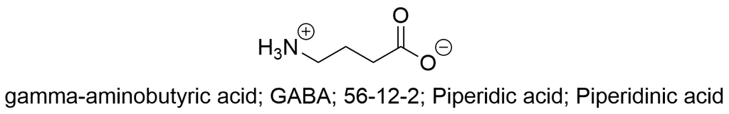

Figure 12.1: GABA

Para o designer de fármacos, o receptor $GABA_A$ Figure 12.2 não deve ser visto como uma entidade estática, mas como uma máquina molecular altamente regulável por múltiplos moduladores alostéricos. O receptor clássico das benzodiazepinas (BZR) é, na verdade, um sítio alostérico específico localizado na interface extracelular entre as subunidades α (particularmente as isoformas α1 ,α2 ,α3 e α5) e γ2. Os ligantes que atuam como agonistas deste sítio não abrem o canal de cloreto de forma direta. Em vez disso, eles agem como moduladores alostéricos positivos (PAMs), estabilizando uma conformação de alta afinidade para o GABA, o que aumenta de forma marcante a frequência de abertura do poro iônico em resposta ao neurotransmissor. Estruturalmente, a arquitetura do sítio BZR exige interações eletrostáticas e de empilhamento π-π específicas, onde um resíduo de histidina conservado na subunidade α atua como um doador essencial de próton para interagir com o grupo aceitator do fármaco.

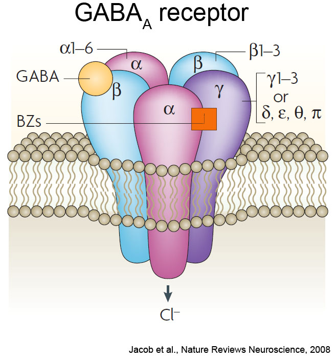

Figure 12.2: Estrutura do Receptor $GABA_A$

Antes da elucidação precisa da neurotransmissão sináptica no século XX, o controle da ansiedade patológica — outrora classificada sob a ampla terminologia de “neuroses” — apoiava-se em substâncias químicas de baixa seletividade e elevada toxicidade. Em meados do século XIX, os sais de brometo (como KBr e NaBr) foram introduzidos de forma serendípica na medicina, atuando como depressores inespecíficos do SNC ao mimetizar termodinamicamente o íon cloreto na membrana celular Figure 12.3. Paralelamente, o hidrato de cloral (sintetizado em 1832), caracterizado quimicamente por um grupo gem-diol adjacente a três átomos de cloro indutores de eletronegatividade, destacou-se como um pró-fármaco capaz de ser reduzido in vivo ao tricloroetanol, potencializando de forma inespecífica a neurotransmissão inibidora. Esses compostos rudimentares sofriam de janelas terapêuticas estreitas e toxicidade cumulativa severa, como o bromismo, clamando pelo desenvolvimento de novos compostos ativos.

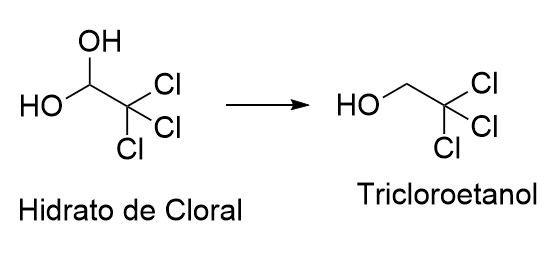

Figure 12.3: Fármacos rudimentares para o tratamento da ansiedade

A verdadeira era da farmacoterapia sedativa iniciou-se no alvorecer do século XX com a introdução dos barbitúricos, derivados cíclicos da malonilureia sintetizados originalmente por Adolf von Baeyer em 1864. Embora o ácido barbitúrico em si seja desprovido de atividade psicotrópica, a substituição dissubstituída na posição C5 do anel pirimidínico gerou compostos lipofílicos altamente potentes, como o barbital (1903) e o fenobarbital (1912) Figure 12.4. Estruturalmente, o tamanho, a ramificação e o caráter aromático dos substituintes em C5 governam a lipofilicidade (logP) e a estabilidade metabólica dessas moléculas, determinando se o fármaco terá ação ultra-curta, intermediária ou longa. No entanto, o calcanhar de Aquiles dos barbitúricos reside em seu mecanismo molecular: em doses elevadas, eles não apenas prolongam a abertura do canal de cloreto na presença de GABA, mas também conseguem abrir diretamente o canal na ausência do neurotransmissor. Essa falta de efeito “teto” molecular explica a facilidade com que induzem depressão respiratória de desfecho fatal, o que restringiu severamente seu uso clínico continuado para a ansiedade.

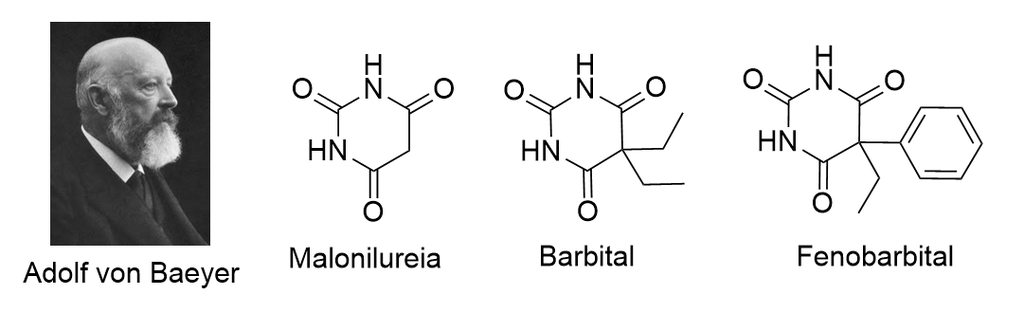

Figure 12.4: Estruturas dos fármacos barbitúricos

Na década de 1950, a busca por uma terapêutica que separasse de forma eficaz os efeitos ansiolíticos da sedação profunda e do risco de óbito levou ao desenvolvimento do meprobamato Figure 12.5 (comercializado em 1955 como Miltown®). Sintetizado por Frank Berger como um derivado dicarbamato do relaxante muscular mefenesina, o meprobamato possuía uma estrutura bis-carbamato simétrica ancorada em um esqueleto de 1,3-propanodiol substituído. Sob o ponto de vista farmacoterapêutico, o meprobamato atuou como uma ponte conceitual histórica, sendo o primeiro fármaco a ser amplamente rotulado e comercializado como um “tranquilizante menor”, demonstrando que era quimicamente viável mitigar a tensão psíquica com menor comprometimento cognitivo e motor em relação aos barbitúricos. Contudo, o meprobamato revelou-se um modulador GABAérgico inespecífico que ainda compartilhava riscos significativos de tolerância, abuso e overdoses perigosas, mantendo aberta a corrida científica por uma classe farmacofórica superior.

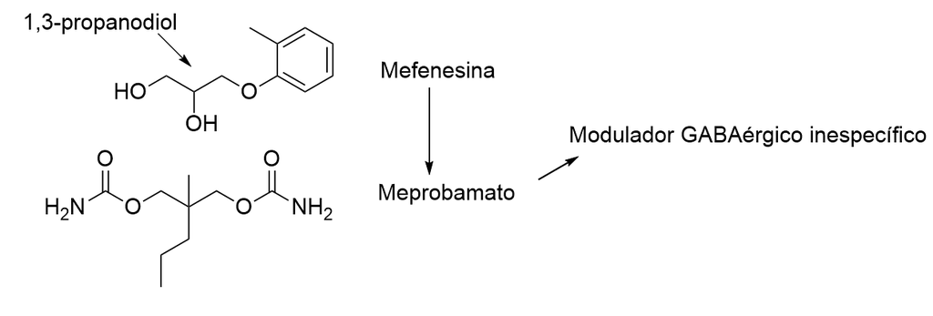

Figure 12.5: Descoberta do Meprobamato

## 12.1 Descoberta do clordiazepóxido

A história das benzodiazepinas está indissociavelmente ligada à genialidade e à resiliência de Leo Henryk Sternbach (1908–2005) Figure 12.6. Nascido em Opatija, no antigo Império Austro-Húngaro, Sternbach obteve seu doutorado em química orgânica em 1931 pela Universidade Jaguelônica de Cracóvia, na Polônia. Em 1940, iniciou suas pesquisas nos laboratórios da Hoffmann-La Roche em Basileia, Suíça. Contudo, devido à perseguição antissemita promovida pelo regime nazista durante a Segunda Guerra Mundial, Sternbach foi forçado a fugir da Europa em 1941, emigrando para os Estados Unidos, onde se estabeleceu permanentemente na sede norte-americana da Roche em Nutley, Nova Jersey. Em meados da década de 1950, estimulado pelo sucesso clínico estrondoso da clorpromazina (lançada na França em 1952) e fascinado por sua estrutura tricíclica, Sternbach propôs uma hipótese ousada: ele decidiu investigar uma classe de compostos que havia sintetizado duas décadas antes na Polônia, durante seus estudos de pós-graduação com corantes têxteis. Estes compostos eram descritos na literatura química alemã clássica como “benzheptoxdiazinas” (estruturas com anel fundido de sete membros contendo oxigênio e nitrogênio). Sternbach teorizou que a introdução de cadeias alquilamino básicas nesses esqueletos inertes mimetizaria os farmacóforos das fenotiazinas tranquilizantes, criando novos e promissores agentes psicotrópicos.

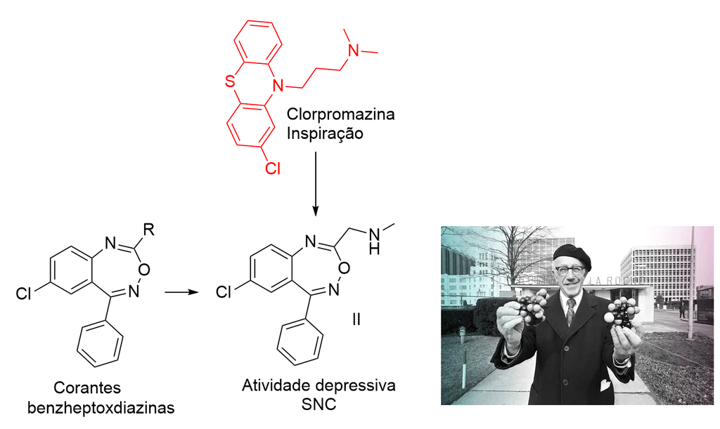

Figure 12.6: Inspirações de Leo Henryk Sternbach

Para executar seu plano de design de fármacos, Sternbach desenhou uma rota sintética visando a funcionalização do carbono exocíclico de uma série de halometil heterociclos. Investigações estruturais subsequentes revelaram o primeiro grande erro de caracterização do projeto: os compostos de partida que ele acreditava serem “benzheptoxdiazinas” eram, na verdade, quinazolina 3-óxidos. O intermediário eletrofílico chave gerado para os acoplamentos nucleofílicos foi o 6-cloro-2-clorometil-4-fenilquinazolina 3-óxido. O grupo de Sternbach submeteu este intermediário a reações sistemáticas com diversas aminas secundárias (como a dimetilamina), buscando obter os correspondentes derivados de substituição nucleofílica alifática normal, como o 6-cloro-2-dimetilaminometil-4-fenilquinazolina 3-óxido. Entretanto, todos os cerca de 40 análogos obtidos por essa via mostraram-se completamente desprovidos de atividade sedativa, anticonvulsivante ou relaxante muscular nos ensaios biológicos de triagem. Diante do aparente fracasso, o projeto foi engavetado em 1955. Somente em maio de 1957, durante uma limpeza de rotina no laboratório, o assistente Earl Reeder encontrou um frasco contendo um resíduo cristalino purificado, codificado como Ro 5-0690 Figure 12.7, obtido a partir de uma reação realizada com metilamina (uma amina primária), que ainda não havia sido testada. Ao ser enviada aos testes biológicos, a substância demonstrou propriedades depressoras do SNC incomparavelmente superiores ao meprobamato e com uma margem de segurança nunca antes vista.

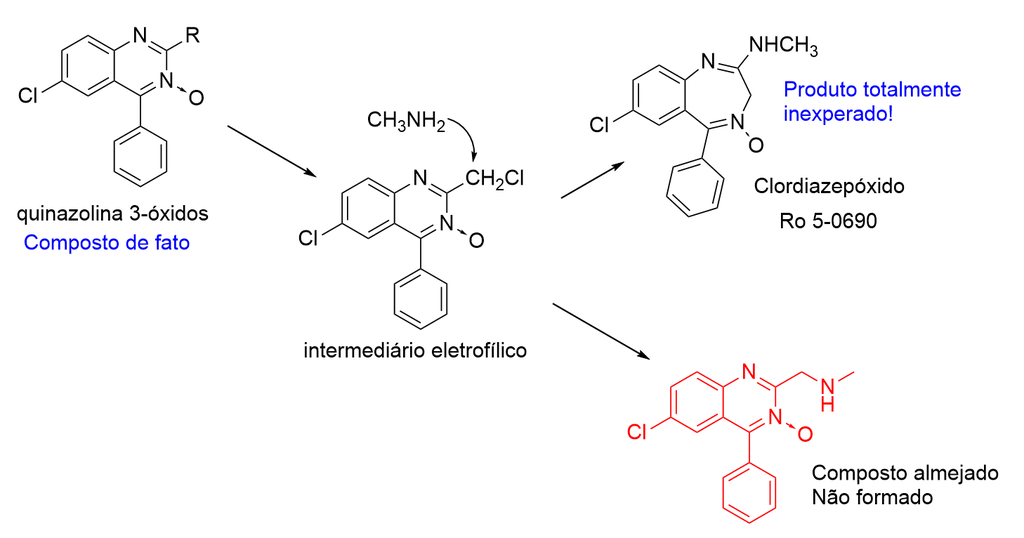

Figure 12.7: Produto enerperado, a expansão do anel

A análise química minuciosa do composto Ro 5-0690 Figure 12.7 (inicialmente denominado metaminodiazepóxido e, posteriormente, clordiazepóxido) revelou que a reação do 6-cloro-2-clorometil-4-fenilquinazolina 3-óxide com a metilamina não seguiu a substituição convencional observada com as aminas secundárias. Por ser menos impedida estericamente e mais nucleofílica, a metilamina atacou diretamente o carbono C2 do anel de quinazolina, provocando a abertura hidrolítica do heterociclo de seis membros, seguida de um fechamento intramolecular com expulsão do cloreto da cadeia lateral clorometil. Esse rearranjo expandiu o anel pirimidínico para um sistema diazepínico de sete membros, gerando o 7-cloro-2-metilamino-5-fenyl-3H-1,4-benzodiazepine 4-óxido.

## 12.2 Relação Estrutura-Atividade e a Simplificação Racional

A compreensão da relação estrutura-atividade (SAR) dos moduladores alostéricos do receptor $GABA_A$ representa um dos capítulos mais instrutivos da química medicinal moderna. O andaime molecular clássico das benzodiazepinas consiste em um sistema tricíclico fundido de alta complementaridade topográfica com o sítio alostérico das subunidades α/γ do receptor. Este arcabouço é estruturado por um anel benzênico (Anel A), fundido a um anel diazepínico de sete membros contendo dois nitrogênios nas posições 1 e 4 (Anel B), o qual sustenta um anel fenílico pendente na posição C5 (Anel C). Embora milhares de derivados tenham sido sintetizados nas últimas décadas, a exploração sistemática de modificações químicas nos anéis A, B e C revelou limites bioisostéricos rígidos, onde pequenas alterações eletrônicas ou estéricas são capazes de ditar se a molécula atuará como agonista pleno (ansiolítico/sedativo), antagonista neutro ou agonista inverso (pró-convulsivante/ansiógeno).

O Anel A Figure 12.8 (núcleo aromático correspondente às posições 6 a 9) participa ativamente de interações de empilhamento hidrofóbico (π-π stacking) com resíduos de aminoácidos aromáticos na interface α/γ do receptor $GABA_A$. A regra cardeal de SAR para o Anel A estabelece que substituintes fortemente eletronegativos na posição C7 aumentam drasticamente a potência ansiolítica in vivo. O cloro (como no diazepam e clordiazepóxido) e o grupo nitro ($−NO_2$), como no clonazepam e nitrazepam são os substituintes mais eficientes, promovendo um balanço eletrônico ideal para a estabilização do complexo receptor-fármaco.

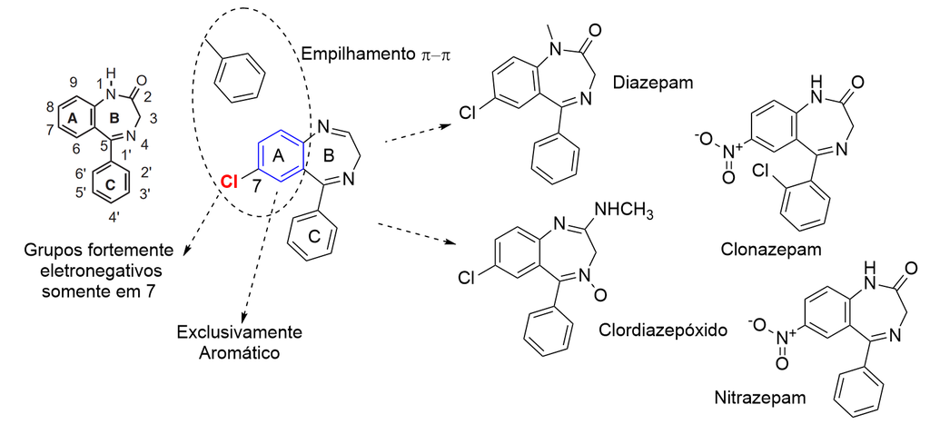

Figure 12.8: REA anel análise do anel A

Deslocamento de Posição: A introdução de substituintes eletronegativos nas posições vizinhas C6, C8 ou C9 resulta em perda quase completa da atividade ansiolítica, evidenciando que a densidade eletrônica polarizada deve estar estritamente concentrada no vetor da posição 7.

Substituição Heterocíclica: Tentativas de substituir o anel benzênico A por sistemas heterocíclicos alternativos geraram compostos com afinidade de ligação in vitro extremamente fraca e nulidade terapêutica in vivo, demonstrando que o caráter plano e a aromaticidade do anel fenílico são insubstituíveis para o acoplamento correto ao receptor.

O Anel B Figure 12.9 (diazepínico de sete membros) é o centro conformacional da molécula. Ele adota preferencialmente uma conformação em barco dinamicamente flexível, onde estudos estereoquímicos com o enantiômero S do 3-metildiazepam demonstraram que a configuração S estabiliza a conformação ativa do anel que interage de forma estereoespecífica com o receptor. Na posição C2, a presença de um grupo aceitador de ligação de hidrogênio (como a carbonila, C=O) coplanar ao Anel A é um requisito absoluto para a eficácia ansiolítica . Esse oxigênio carbonílico atua emparelhando-se com um resíduo crítico de histidina localizado na subunidade α1 do receptor $GABA_A$.

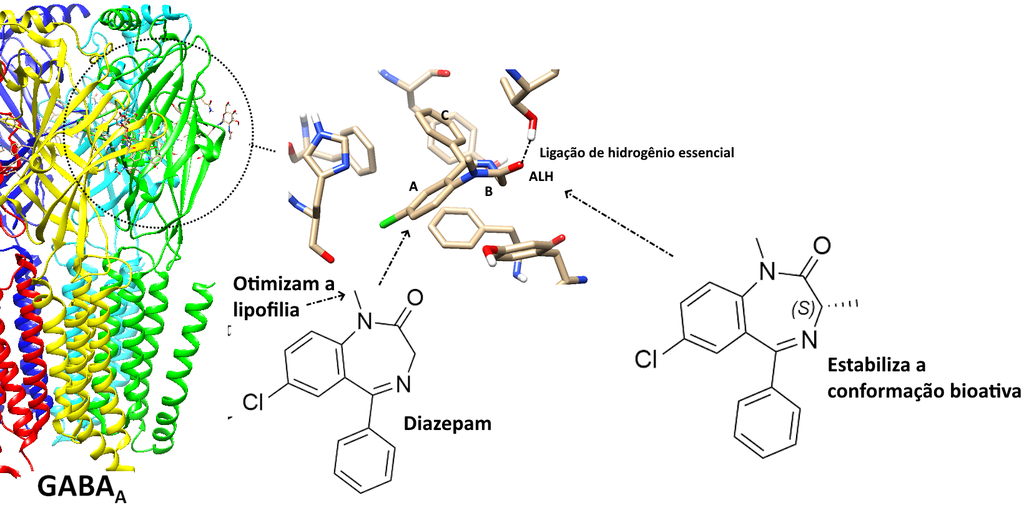

Figure 12.9: REA anel análise do anel B

No nitrogênio amídico N1, substituintes alquílicos pequenos como o grupo metila (−CH3 no diazepam) otimizam a lipofilicidade e a estabilidade metabólica. Contudo, substituintes volumosos como o grupo tert-butil no nitrogênio N1 colapsam a afinidade pelo receptor, devido ao severo impedimento estérico que impede a aproximação do fármaco ao sítio ativo.

Na posição C3 Figure 12.10, a introdução de um grupo hidroxila (−OH) representa uma das estratégias de maior sucesso na química farmaceutica da classe, originando fármacos como o oxazepam e o lorazepam. Sob a perspectiva farmacocinética, a hidroxila em C3 serve como um “ancoradouro de fase II”, permitindo que a molécula seja diretamente conjugada com ácido glicurônico no fígado, eliminando a dependência do metabolismo oxidativo do Citocromo P450 (Fase I). Isso previne o acúmulo de metabólitos ativos de meia-vida longa, tornando o lorazepam e o oxazepam substancialmente mais seguros para administração em pacientes idosos ou hepatopatas. Na posição C3, também é possível introduzir um grupo carboxila (−COOH), como no clorazepato; este atua como um pró-fármaco hidrossolúvel estável que sofre descarboxilação rápida no pH ácido do estômago para gerar o metabólito ativo nordiazepam, promovendo uma absorção altamente previsível.

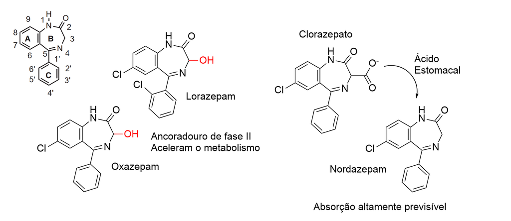

Figure 12.10: Grupos polares em C3 do anel B

O Anel C (5-fenil pendente) Figure 12.11 projeta-se em um plano angulado em relação ao sistema bicíclico A-B, estabelecendo interações hidrofóbicas acessórias que estabilizam a conformação bioativa do heterociclo. Embora o anel fenílico C não seja estritamente indispensável para a ligação basal in vitro, sua manipulação química revela regras rígidas de substituição espacial:

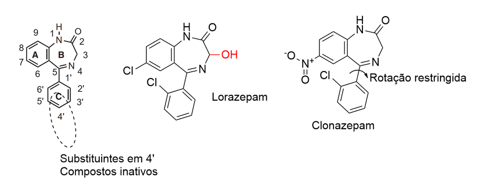

Figure 12.11: REA anel análise do anel C

## 12.3 Fusão Heterocíclica (Triazol e Imidazobenzodiazepinas)

A evolução estrutural da segunda geração de ansiolíticos focou na anelação das posições 1 e 2 do Anel B com um anel heterocíclico adicional rico em elétrons, como o s-triazol ou o imidazol. Essa anelação 1,2 gerou sistemas tetracíclicos planos altamente estáveis, eliminando o nitrogênio amídico livre e a necessidade de metilação em N1. O maior expoente de sucesso dessa estratégia é o alprazolam Figure 12.12 (uma s-triazol-benzodiazepina). A fusão do anel triazol conferiu-lhe uma afinidade extremamente elevada pelo receptor $GABA_A$ e propriedades farmacodinâmicas únicas, como uma atividade antipânico adicional que revolucionou a terapêutica clínica. Outro triunfo da engenharia molecular foi o midazolam Figure 12.12 (uma imidazobenzodiazepina).

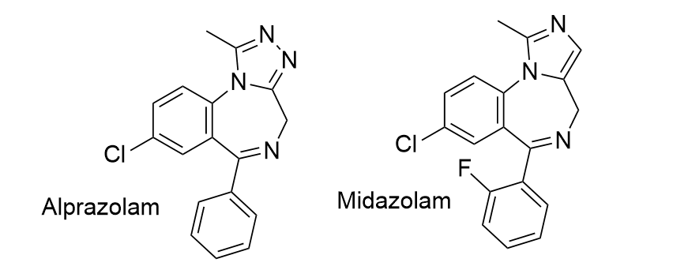

Figure 12.12: Fusão Heterocíclica (Triazol e Imidazobenzodiazepinas)

Outro triunfo da engenharia molecular foi o midazolam (uma imidazobenzodiazepina). O midazolam apresenta uma propriedade físico-química pH-dependente fascinante: o nitrogênio básico do anel imidazol fundido possui um pKa de aproximadamente 6,2. Sob condições ácidas em formulação farmacêutica (pH ~3), o nitrogênio é protonado, promovendo a abertura catalisada por ácido da ligação imínica 4,5 do anel diazepínico e convertendo cerca de 80% da solução em uma estrutura aberta altamente hidrossolúvel. Isso permite sua formulação em solução aquosa estável e indolor para administração intravenosa ou intramuscular, eliminando a necessidade de veículos orgânicos irritantes. No entanto, ao ser injetado e entrar em contato com o pH fisiológico do sangue (7,4), a base livre é regenerada; o anel diazepínico fecha-se espontaneamente por reação de ciclização intramolecular, restaurando 100% da molécula em sua conformação tetracíclica ativa e altamente lipofílica, que atravessa imediatamente a barreira hematoencefálica para produzir sedação e anxiólise ultrarrápidas.

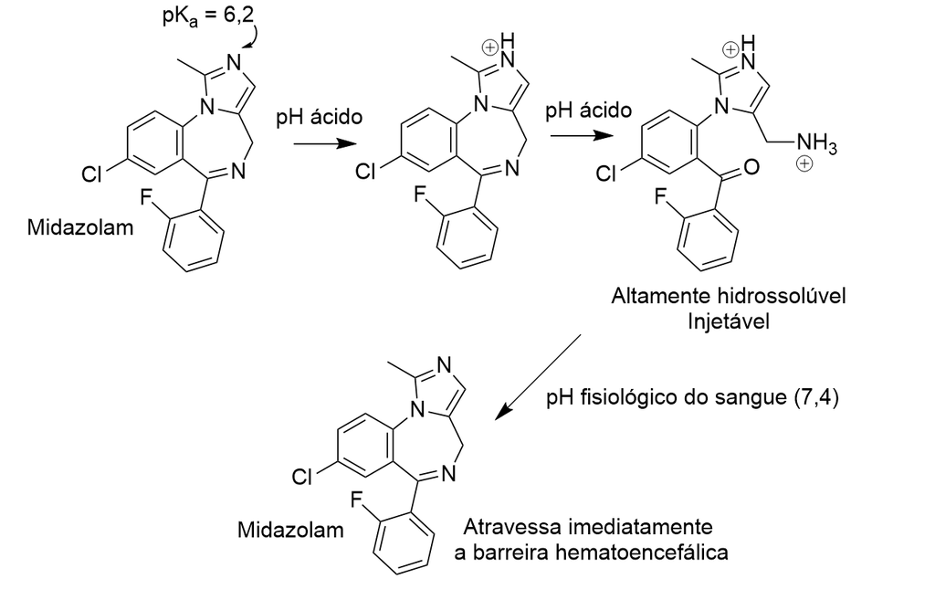

Figure 12.13: Midazolam um fármaco injetável por um motivo extraordinário

## 12.4 Moduladores Parciais e Não-Benzodiazepínicos

O Fracasso do Bretazenil e do Abecarnil: O bretazenil Figure 12.14 (um agonista parcial imidazobenzodiazepínico) e o abecarnil (um derivado $\beta$-carbolínico parcial) demonstraram uma anxioseletividade espetacular em modelos animais pré-clínicos, exibindo efeitos ansiolíticos com margens de segurança imensas e ausência de sedação ou relaxamento muscular. Contudo, nos ensaios clínicos em humanos, o perfil anxioseletivo previsto falhou completamente em se materializar. O bretazenil continuou a induzir níveis intoleráveis de sedação de forma dose-dependente em humanos, o que forçou o abandono imediato de seu desenvolvimento clínico.

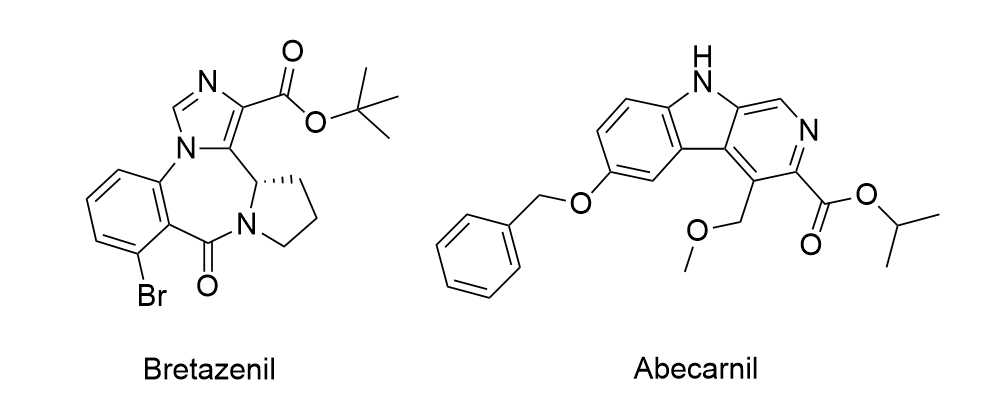

Figure 12.14: Bretazenil e Abecarnil

O Fracasso do Alpidem e do Ocinaplon Figure 12.15 (Toxicidade Orgânica): Na classe dos ligantes não-benzodiazepínicos seletivos pela subunidade $\alpha_1$ (responsáveis por interagir com o receptor BZR clássico), o alpidem (uma imidazopiridina) demonstrou eficácia clínica ansiolítica comparável ao lorazepam, porém com menor comprometimento cognitivo e motor. Apesar de ter chegado ao mercado europeu, o alpidem teve de ser abruptamente retirado do mercado global devido a relatos severos de hepatotoxicidade fulminante. Destino idêntico sofreu o ocinaplon (um derivado pyrazolopirimidínico desenvolvido como ansiolítico seletivo), cujo desenvolvimento clínico foi definitivamente descontinuado após a confirmação de toxicidade hepática grave em voluntários e pacientes.

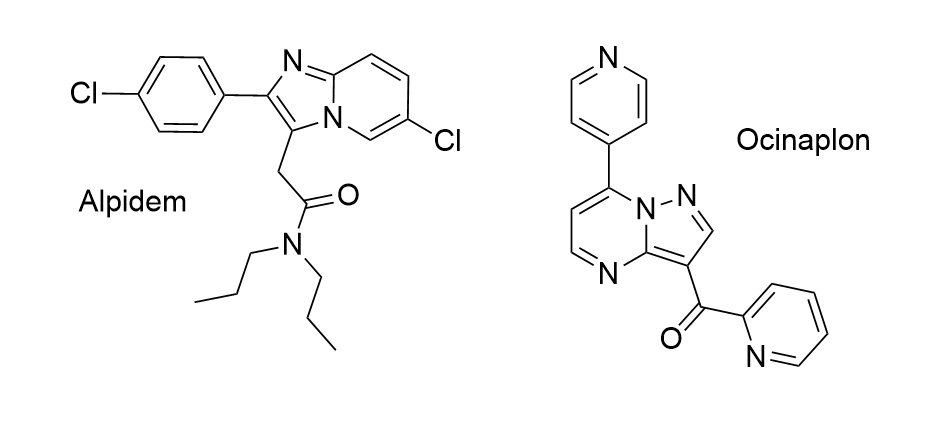

Figure 12.15: Alpidem e Ocinaplon

## 12.5 Agonistas Não-Benzodiazepínicos (Z-Fármacos)

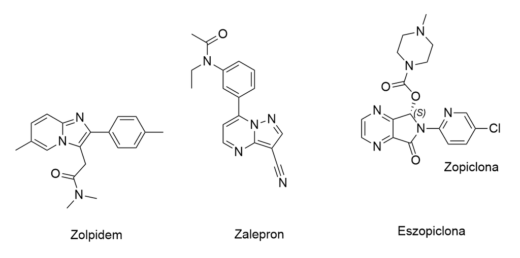

Figure 12.16: Z-fármacos, Zolpidem, zeleplon e eszopiclina

Embora apresentem estruturas químicas heterocíclicas divergentes das 1,4-benzodiazepinas, os Z-fármacos ligam-se ao mesmo sítio alostérico localizado na interface extracelular $\alpha/\gamma_2$ do receptor $\text{GABA}_A$. Estruturas cristalográficas mostram uma sobreposição farmacofórica demonstram que essas moléculas planas e ricas em elétrons mimetizam os vetores essenciais das benzodiazepinas, posicionando um átomo aceptor de ligação de hidrogênio e sistemas aromáticos de empilhamento $\pi$-$\pi$ em coordenadas espaciais quase idênticas.

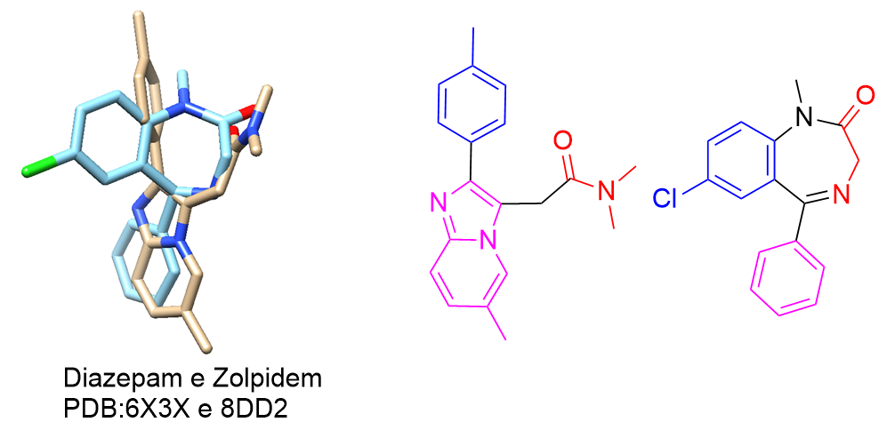

Figure 12.17: Diazepam e Zolpiem sobrepostos na estrutura cristalográfica

Os Z-fármacos (zolpidem, zaleplon e eszopiclone) revolucionaram o tratamento da insônia pela sua seletividade. Ao contrário dos benzodiazepínicos antigos, que agem de forma generalizada no cérebro, esses novos compostos “escolhem” alvos específicos. O zolpidem foca na subunidade $α_1$, promovendo sono rápido com poucos efeitos colaterais de relaxamento muscular ou amnésia. Já o eszopiclone (a isômero ativo do zopiclone) vai além: ele também atua nas subunidades $α_2$ e $α_3$, o que ajuda a controlar a ansiedade e estabilizar o humor, sendo ideal para pacientes que sofrem de insônia e transtornos psiquiátricos simultaneamente.

A outra grande vantagem é a limpeza metabólica. Enquanto fármacos como o diazepam permanecem no organismo por dias e geram resíduos ativos que causam a “ressaca” matinal (hangover), os Z-fármacos são eliminados rapidamente. O zaleplon é ultra-curto, ideal apenas para pegar no sono; o zolpidem oferece um equilíbrio para o início da noite sem acumular no organismo; e o eszopiclone tem duração moderada, sendo eficaz para manter o sono a noite toda sem causar o prejuízo motor e a sonolência excessiva no dia seguinte, comuns nas medicações de longa duração.

Embora os moduladores não-benzodiazepínicos do receptor $\text{GABA}_A$ (Z-fármacos) tenham sido introduzidos sob a promessa comercial de maior tolerabilidade, a prática terapêutica consolidou uma série de limitações importantes na classe, demonstrando que as benzodiazepinas tradicionais ainda mantêm uma clara superioridade clínica em múltiplos cenários. Sob o ponto de vista da seletividade farmacofórica, por possuírem afinidade voltada quase que exclusivamente para a subunidade $\alpha_1$, fármacos como o zolpidem e o zaleplon são essencialmente desprovidos de atividade ansiolítica primária, de modo que suas ações limitam-se de forma estrita ao efeito sedativo-hipnótico.

Essa seletividade representa uma grave desvantagem terapêutica em comparação com o agonismo alostérico não seletivo das benzodiazepinas clássicas (que modulam simultaneamente as subunidades $\alpha_1, \alpha_2, \alpha_3$ e $\alpha_5$), uma vez que até 80% dos pacientes que sofrem de insônia apresentam transtornos de ansiedade ou quadros depressivos comórbidos que exigem intervenção clínica direta sobre o humor. Além do espectro restrito, os Z-fármacos falharam em eliminar o “lado escuro” da modulação GABAérgica: estudos clínicos de longo prazo confirmam que o uso crônico dessas substâncias compartilha com as benzodiazepinas altos riscos de tolerância, dependência física, insônia rebote e declínio cognitivo gradual.

# 13 Neuroesteroides e a Revolução da Inibição GABAérgica Tônica

A conceitualização dos esteroides como agentes puramente endócrinos, restritos à modulação genômica de longa latência via receptores nucleares, sofreu uma quebra profunda de paradigma com a descoberta dos neuroesteroides (NS). O termo, introduzido originalmente pelo fisiologista francês Étienne-Émile Baulieu na década de 1990, define uma classe única de esteroides que são sintetizados de novo no sistema nervoso central (SNC) a partir do colesterol, de forma independente das glândulas endócrinas periféricas. Sob a perspectiva da biogênese molecular, a etapa limitante da síntese de neuroesteroides é a translocação hidrofóbica do colesterol da membrana mitocondrial externa para a interna, um processo catalisado ativamente pela Proteína Translocadora de 18 kDa (TSPO) — anteriormente denominada receptor benzodiazepínico periférico Figure 13.1.

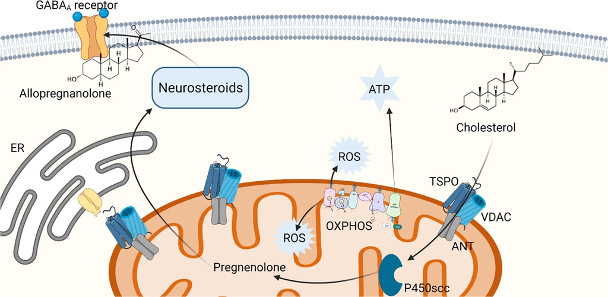

Figure 13.1: O TSPO é expresso na membrana mitocondrial externa (OMM) e associado a outras proteínas, como a VDAC e o transportador de nucleotídeos de adenina (ANT), formando um supercomplexo. O TSPO está envolvido na translocação de colesterol do citosol para a matriz mitocondrial, onde ele é convertido em pregnenolone pela atividade da P450scc. Após a difusão para fora da mitocôndria, a pregnenolona é metabolizada em neuroesteróides, por exemplo, alopregnanolona, no citosol e no retículo endoplasmático (RE). A alopregnanolona é um modulador positivo no receptor $GABA_A$. Além disso, o TSPO influencia a geração de ATP e de espécies reativas de oxigênio (ROS) por meio do sistema de fosforilação oxidativa (OXPHOS).

Em concentrações nanomolares, a alopregnanolona Figure 13.1 e seu isômero estereoquímico pregnanolone atuam como os moduladores alostéricos positivos (PAMs) mais potentes conhecidos do receptor (${GABA}_A$) cerebral, induzindo efeitos ansiolíticos, anticonvulsivantes e sedativos imediatos através de mecanismos rápidos de membrana (não-genômicos).

Diferentemente dos ansiolíticos clássicos, a complementaridade tridimensional dos neuroesteroides ao receptor $GABA_A$ impõe dinâmicas alostéricas e seletividades de subunidades totalmente distintas. Enquanto a atividade farmacológica das benzodiazepinas (BZDs) exige estritamente a interface de ligação extracelular e varia criticamente de acordo com a composição das isoformas, os neuroesteroides ligam-se a uma cavidade lipofílica e hidrofóbica localizada no domínio transmembranar. O requisito farmacofórico fundamental e absoluto para o acoplamento correto dos neuroesteroides reside na orientação estereoficiente do grupo 3($\alpha$)-hidroxila no Anel A da estrutura esteroidal saturada, a qual interage de forma tridimensional com os resíduos de aminoácidos do canal.

Sob a perspectiva da eficácia intrínseca, em baixas concentrações nanomolares, os neuroesteroides atuam como PAMs estritos; contudo, em concentrações micromolares elevadas, eles exercem um efeito agonista direto (abertura direta do poro de cloreto) mesmo na ausência completa de GABA, expandindo consideravelmente sua eficácia em relação ao efeito “teto” limitado das benzodiazepinas.

A aplicação terapêutica dos neuroesteroides endógenos enfrentou, historicamente, duas grandes barreiras químicas: a baixíssima biodisponibilidade por via oral e a rápida metabolização hepática de primeira passagem, a qual oxida a hidroxila essencial em C3 para formar metabólitos com indesejadas ações hormonais progestacionais em receptores nucleares de progesterona Figure 13.2.

Para contornar esse impasse de design de fármacos, químicos medicinais desenvolveram a ganaxolona Figure 13.2. A introdução estratégica de um grupo metila na posição 3($\beta$) bloqueia estericamente a oxidação da hidroxila em C3 para a forma cetônica correspondente, preservando a orientação 3($\alpha$)-hidroxi ativa e eliminando a atividade hormonal periférica, enquanto confere estabilidade metabólica e viabilidade de uso por via oral estável com menor propensão à tolerância farmacológica quando comparada às benzodiazepinas.

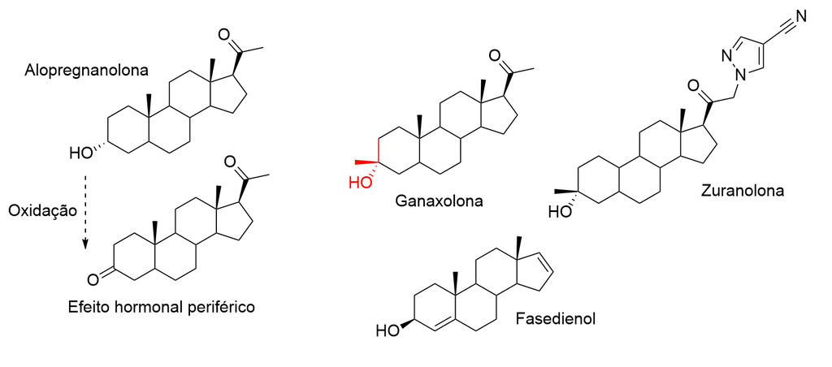

Figure 13.2: Ganaxolona, zuranolona e fasedienol

A brexanolona — que consiste em uma formulação aquosa solubilizada em ciclodextrina da alopregnanolona endógena — foi aprovada em 2019 como o primeiro tratamento específico e de resposta ultra-rápida (em horas) para a depressão pós-parto grave. No entanto, sua desvantagem reside na exigência de uma infusão endovenosa contínua monitorada de 60 horas e em seu elevado custo sistêmico. Para solucionar essa lacuna de administração, o análogo oral zuranolona Figure 13.2 (SAGE-217) foi otimizado quimicamente para manter elevada estabilidade sistêmica e atravessar eficientemente a barreira hematoencefálica após deglutição, recebendo aprovação em 2023 para depressão pós-parto e avançando em ensaios de fase 3 para o Transtorno de Ansiedade Generalizada (TAG).

Na vanguarda do desenvolvimento (2024–2026), destaca-se o fasedienol Figure 13.2 (PH94B / Aloradine), um neuroesteroide sintético inovador formulado como spray nasal para o tratamento imediato do Transtorno de Ansiedade Social (fobia fóbica aguda). A engenharia farmacêutica do fasedienol explora uma via de entrega totalmente independente da absorção sistêmica: o fármaco é administrado em microgramas no epitélio nasal, onde se liga seletivamente a quimiorreceptores periféricos das células sensoriais do órgão vomeronasal.

Por atuar localmente e evitar a circulação sanguínea periférica, o fasedienol é isento de metabolismo de primeira passagem e não induz os efeitos adversos clássicos de sedação sistêmica, fadiga, distúrbio cognitivo ou interação com etanol, posicionando-se como uma das maiores promessas de “ansiolítico sob demanda” da psiquiatria moderna.

## 13.1 Gabapentinoides como Moduladores de Canais de Cálcio

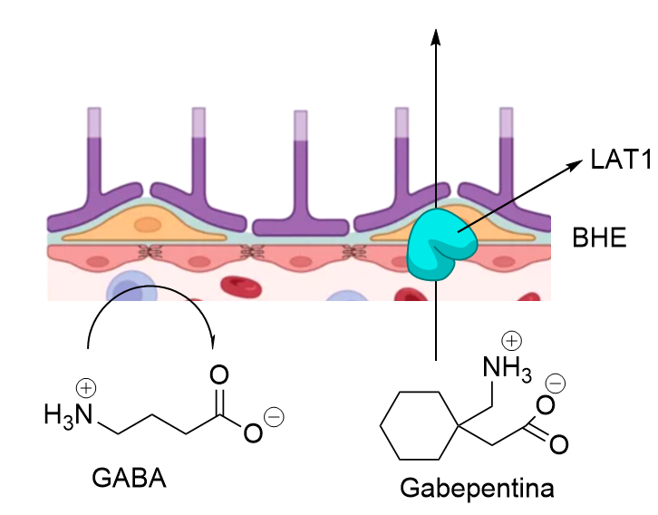

Figure 13.3: Absorção facilitada da gabapentina pelo SNC.

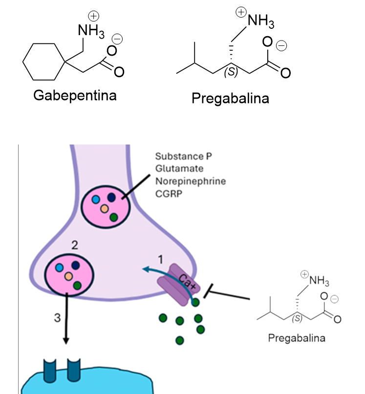

Figure 13.4: Pregabalina e seu mecanismo de ação.

Apesar de terem sido originalmente concebidos como miméticos do neurotransmissor inibitório, os gabapentinoides não interagem com os receptores $\text{GABA}_A$ ou $\text{GABA}_B$, nem alteram de forma direta as correntes de cloreto pós-sinápticas. Em vez disso, seu mecanismo de ação molecular consiste na ligação seletiva e de alta afinidade à subunidade acessória $\alpha_2\delta$ (especificamente as isoformas $\alpha_2\delta-1$ e $\alpha_2\delta-2$) dos canais de cálcio dependentes de voltagem (Cav) do tipo L, N e P/Q nas membranas pré-sinápticas Figure 13.4. A associação do fármaco a essa subunidade extracelular induz uma modulação alostérica que dificulta o tráfego intracelular e a ancoragem desses canais de cálcio na membrana sináptica. O resultado líquido é uma redução marcante no influxo de íons $\text{Ca}^{2+}$ pré-sinápticos durante episódios de hiperexcitabilidade neuronal, o que inibe a fusão de vesículas sinápticas e diminui a liberação excessiva de neurotransmissores excitatórios, principalmente o glutamato, a noradrenalina e a substância P.

## 13.2 Inibidores da Recaptação de Serotonina e Noradrenalina

Embora as benzodiazepinas continuem sendo referências para o controle agudo da ansiedade, a terapêutica de manutenção de longo prazo para transtornos como o Transtorno de Ansiedade Generalizada (TAG), Transtorno do Pânico e Fobia Social consolidou os antidepressivos como agentes de primeira linha farmacológica. Destacam-se os Inibidores Seletivos da Recaptação de Serotonina (ISRSs) — como o escitalopram, a paroxetina, a sertralina e a fluoxetina — e os Inibidores da Recaptação de Serotonina e Noradrenalina (IRSNs) — representados pela venlafaxina e duloxetina. Sob a ótica da neurobiologia molecular, esses fármacos atuam atenuando gradualmente a excitabilidade cerebral através do bloqueio de transportadores monoaminérgicos pré-sinápticos específicos (como o SERT e o NET), aumentando a disponibilidade desses neurotransmissores na fenda sináptica para promover adaptações em receptores pós-sinápticos após semanas de latência adaptativa, com a enorme vantagem clínica de não induzir a tolerância ou a dependência física típica dos moduladores GABAérgicos clássicos. Contudo, devido à extensão e à relevância de suas propriedades estruturais, rotas sintéticas, relações estrutura-atividade (SAR) detalhadas e perfis de biotransformação sistêmica, o estudo aprofundado dessas classes químicas e seus respectivos eutômeros é amplamente abordado no capítulo dedicado exclusivamente aos Fármacos Antidepressivos.

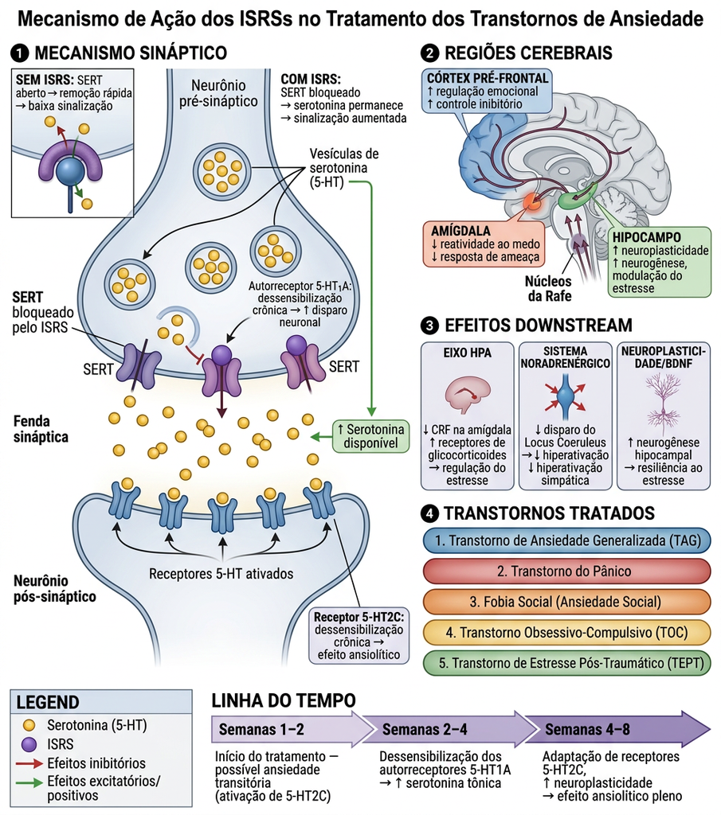

Figure 13.5: Os ISRSs (ex.: sertralina, fluoxetina, escitalopram, paroxetina, fluvoxamina) constituem a primeira linha farmacológica para o tratamento de transtornos de ansiedade, atuando por meio de mecanismos sinápticos, regionais e sistêmicos interconectados.

Em condições basais (inset “SEM ISRSs”), a serotonina (5-HT, esferas douradas Figure 13.5) liberada na fenda sináptica é rapidamente recaptada pelo transportador de serotonina (SERT), limitando a magnitude e a duração do sinal serotoninérgico. Com a administração de um ISRS (painel principal), a molécula do fármaco (esfera roxa) se liga de forma seletiva ao SERT, bloqueando-o e impedindo a recaptação da 5-HT. O resultado imediato é o acúmulo de serotonina na fenda sináptica (↑ serotonina disponível) e a consequente ativação persistente dos receptores 5-HT pós-sinápticos.

Dois subtipos de receptores modulam a resposta ao longo do tratamento:

Autorreceptor 5-HT₁A pré-sináptico: inicialmente, o excesso de 5-HT ativa esse autorreceptor, reduzindo o disparo neuronal como mecanismo de retroalimentação negativa. Com o uso crônico, ocorre dessensibilização desse autorreceptor, desinibindo o neurônio serotoninérgico e sustentando níveis elevados de 5-HT.

Receptor 5-HT₂C pós-sináptico: a ativação aguda deste receptor pode produzir um efeito transitoriamente ansiogênico nas primeiras semanas de tratamento. A dessensibilização crônica do 5-HT₂C é considerada um dos principais mecanismos responsáveis pelo efeito ansiolítico pleno dos ISRSs.

Os efeitos serotoninérgicos mediados pelos ISRSs se distribuem pelo cérebro a partir das projeções dos Núcleos da Rafe (principal fonte de 5-HT no SNC), alcançando três regiões centrais nos transtornos de ansiedade:

Amígdala (laranja): estrutura-chave no processamento do medo e detecção de ameaças. Os ISRSs reduzem sua reatividade, diminuindo respostas de medo condicionado e comportamentos defensivos excessivos. Córtex Pré-Frontal (azul): responsável pela regulação emocional top-down e pelo controle inibitório sobre a amígdala. O aumento de 5-HT nessa região fortalece a modulação cognitiva das emoções. Hipocampo (verde): envolvido na memória contextual do medo e na regulação do eixo do estresse. Os ISRSs promovem neuroplasticidade e neurogênese hipocampal, contribuindo para a resiliência ao estresse.

Além da modulação serotoninérgica direta, os ISRSs produzem adaptações em sistemas relacionados:

Eixo HPA (Hipotálamo–Hipófise–Adrenal): a serotonina reduz a liberação de CRF (fator liberador de corticotropina) na amígdala central e aumenta a densidade de receptores de glicocorticoides no hipocampo e hipotálamo, restaurando a regulação do eixo do estresse frequentemente hiperativado nos transtornos de ansiedade.

Sistema Noradrenérgico: o tratamento prolongado com ISRSs atenua progressivamente o disparo dos neurônios noradrenérgicos do Locus Coeruleus, reduzindo a hiperativação simpática (taquicardia, sudorese, hipervigilância) característica de estados ansiosos.

Neuroplasticidade/BDNF: os ISRSs promovem a expressão do BDNF (fator neurotrófico derivado do encéfalo) e estimulam a neurogênese hipocampal adulta, processos associados à recuperação funcional e à resiliência ao estresse crônico.

## 13.3 CBD

O CBD Figure 13.6 é um fitocanabinoide não psicoativo extraído da Cannabis sativa que atua por múltiplos alvos moleculares para produzir efeitos ansiolíticos. Diferentemente do Δ9-tetrahidrocanabinol (THC) Figure 13.6, o CBD não é agonista direto do receptor CB1 e não produz efeitos psicoativos, sendo considerado um candidato terapêutico seguro para transtornos de ansiedade.

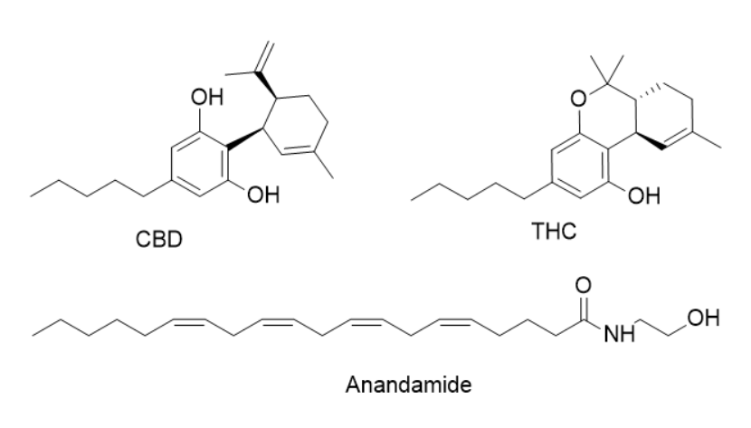

Figure 13.6: Estrutura química do Canabidiol (CBD), Δ9-tetrahidrocanabinol (THC) e o endocanabinoide anandamida (AEA)

Diferentemente dos ISRSs (que atuam primariamente no transportador de serotonina), o CBD apresenta um mecanismo de ação multialvo — ele atua simultaneamente em diferentes receptores e sistemas de neurotransmissão, o que explica tanto a amplitude de seus efeitos quanto a complexidade de sua farmacologia.

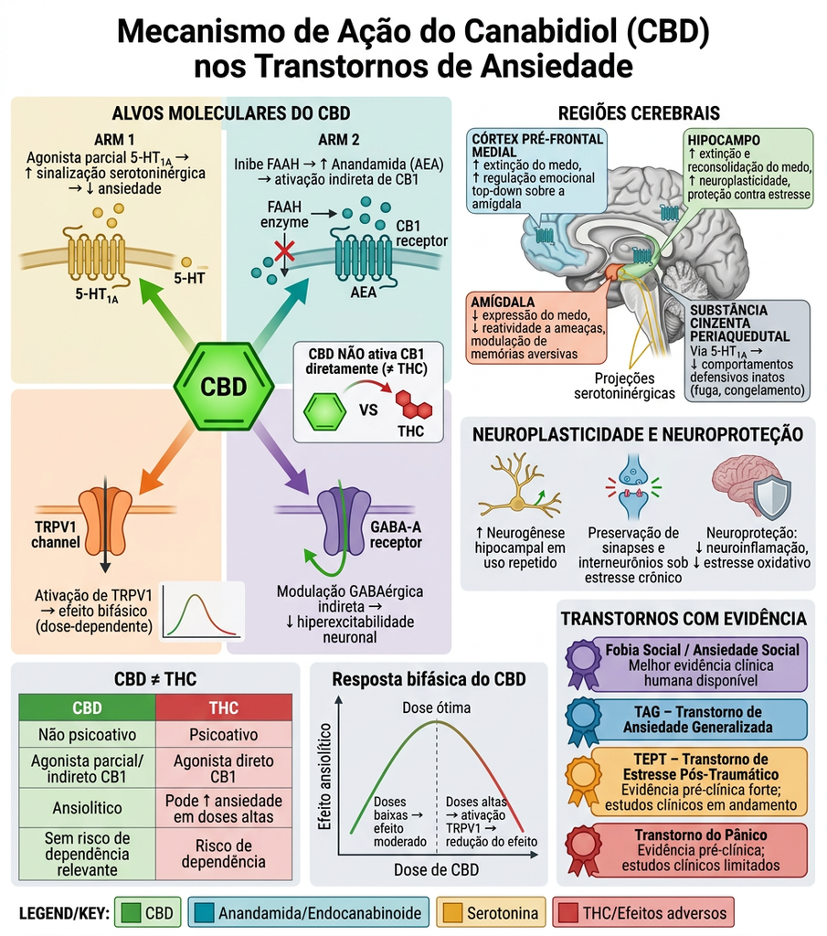

Figure 13.7: Mecanismo de ação do Canabidiol (CBD) nos transtornos de ansiedade.

Os efeitos do CBD convergem sobre quatro regiões-chave no circuito do medo e da ansiedade:

- Amígdala: reduz a expressão do medo condicionado e a reatividade a estímulos ameaçadores, modulando a consolidação de memórias aversivas.
- Córtex pré-frontal medial: fortalece a regulação emocional descendente sobre a amígdala e facilita a extinção de memórias de medo — processo fundamental no tratamento do TEPT.
- Hipocampo: promove neuroplasticidade, estimula a neurogênese e protege o tecido nervoso contra os danos do estresse crônico.
- Substância cinzenta periaquedutal (PAG): via receptores 5-HT₁A, reduz comportamentos defensivos inatos, como fuga e congelamento, especialmente relevantes no transtorno do pânico.

O THC é um agonista direto e potente do receptor CB1, o que provoca euforia, distorções perceptivas e pode, paradoxalmente, aumentar a ansiedade em doses elevadas ou em indivíduos sensíveis. O CBD, ao contrário, atua indiretamente no sistema endocanabinoide (via FAAH/anandamida), pode até modular negativamente o receptor CB1 (reduzindo alguns efeitos do THC), e tem perfil farmacológico favorável, sem risco relevante de dependência ou psicose.

Considerações clínicas importantes O efeito ansiolítico do CBD é dose-dependente e bifásico — doses excessivas podem ser menos eficazes. A maioria dos estudos clínicos robustos utilizou administração aguda; dados sobre uso crônico em humanos ainda são limitados. O CBD possui boa tolerabilidade e poucos efeitos adversos reportados em doses terapêuticas (sonolência, alterações de apetite, diarreia em doses altas). Pesquisas em andamento buscam definir doses ideais, vias de administração e janelas terapêuticas para cada transtorno específico.

Com base no estudo de revisão sistemática e meta-análise https://doi.org/10.1016/j.psychres.2024.116049 publicado por Han et al. (2024) na revista Psychiatry Research diz que a literatura científica preliminar em humanos indica que o Canabidiol (CBD) possui um potencial terapêutico significativo para o tratamento dos transtornos de ansiedade. Os achados sugerem que o CBD pode ser uma ferramenta promissora para aliviar sintomas específicos de ansiedade, atuando como um complemento aos tratamentos convencionais já estabelecidos.

Quais condições podem se beneficiar? O estudo destaca a eficácia do CBD em quadros variados, incluindo:

Transtorno de Ansiedade Generalizada (TAG): caracterizado por preocupação persistente e excessiva. Transtorno de Ansiedade Social (TAS): o medo intenso de interações sociais. Transtorno Obsessivo-Compulsivo (TOC): presença de pensamentos intrusivos e comportamentos repetitivos. Transtorno de Estresse Pós-Traumático (TEPT): reações disfuncionais após eventos traumáticos. É necessário cautela

Apesar dos resultados otimistas — com uma magnitude de efeito considerada substancial (Hedges’ g = -0,92) — a interpretação desses dados exige prudência. Isso ocorre porque o número de ensaios clínicos realizados até o momento ainda é pequeno e envolve poucos participantes em cada estudo (a meta-análise baseou-se em apenas 8 artigos com um total de 316 participantes). Riscos e Segurança

É fundamental considerar os riscos potenciais associados ao uso, que, embora menos frequentes que no caso do THC, ainda precisam de monitoramento, tais como:

Prejuízos em funções cognitivas (memória e atenção); Possibilidade de episódios psicóticos em indivíduos vulneráveis.

O que o futuro nos reserva? Para que o CBD seja incluído de forma segura e oficial nas diretrizes médicas, a ciência ainda precisa responder a perguntas cruciais:

Tratamentos Personalizados: Identificar quais subtipos de ansiedade e níveis de gravidade respondem melhor ao CBD. Dosagem Ideal: Determinar a dose exata que traz o máximo benefício com o mínimo de efeito adverso. Uso a Longo Prazo: Avaliar se a eficácia se mantém e quais são os efeitos colaterais após meses ou anos de uso contínuo. Mecanismos Detalhados: Compreender exatamente como a molécula interage com as engrenagens biológicas do nosso cérebro.

## 13.4 Considerações finais

A análise histórica e molecular dos ansiolíticos revela uma dicotomia complexa entre o benefício terapêutico agudo e os danos sistêmicos associados ao uso prolongado. Pelo lado positivo, a introdução das benzodiazepinas (BZDs) representou um salto extraordinário de segurança em relação aos barbitúricos e carbamatos. Graças ao mecanismo de modulação alostérica positiva (PAM) dependente do GABA, as BZDs oferecem uma janela terapêutica imensamente maior , proporcionando um alívio imediato e altamente eficaz de crises de pânico, agitação severa, fobias e insônia incapacitante. No entanto, o “custo” biológico deste tratamento continuado é severo: o uso crônico está indissociávelmente ligado ao desenvolvimento de tolerância farmacodinâmica, dependência física e psicológica, amnésia anterógrada e uma intensa síndrome de abstinência com insônia rebote. Sob a perspectiva da neurobiologia estrutural recente, descobriu-se um mecanismo celular celular preocupante: fármacos como o diazepam atuam na subunidade mitocondrial transmembranar TSPO, desencadeando uma ativação microglial aberrante que resulta em deposição de proteínas do complemento (C1q) e na remoção fagocítica excessiva de sinapses excitatórias (poda sináptica microglial) no hipocampo e córtex. Esse processo de perda sináptica, embora reversível após a suspensão do fármaco, fornece a primeira elucidação mecânica e celular para o declínio cognitivo e os prejuízos de memória comumente relatados por usuários crônicos de benzodiazepinas.